# Module Three Project

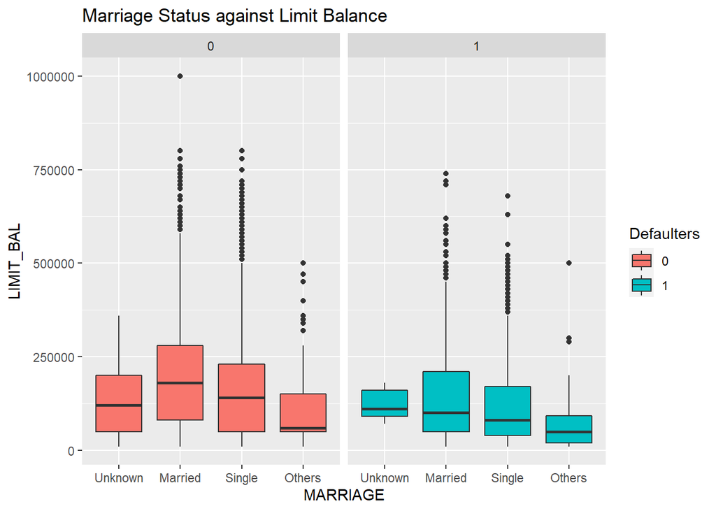

```r
# Marriage status agaist the limit balance
credit <- def
credit$MARRIAGE <- as.factor(credit$MARRIAGE)
levels(credit$MARRIAGE) <- c("Unknown" , "Married" , "Single" ,"Others")
ggplot(data =credit, mapping = aes(group=as.factor(x=MARRIAGE),x=MARRIAGE, y=LIMIT_BAL))+
  geom_boxplot(aes(fill = as.factor(default_payment_next_month)))+
  facet_wrap(~default_payment_next_month)+ guides(fill =guide_legend(title = "Defaulters"))+labs(title='Marriage Status against Limit Balance')
```

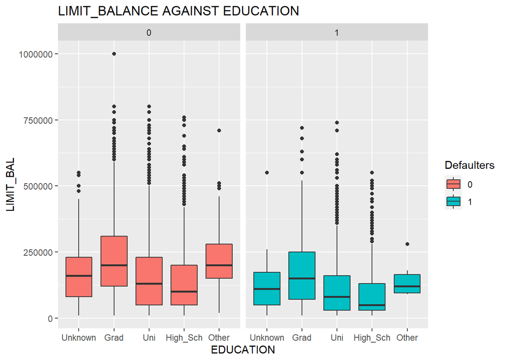

```r
# limit balance against education
credit$EDUCATION <- as.factor(credit$EDUCATION)
levels(credit$EDUCATION) <- c("Unknown", "Grad", "Uni", "High_Sch", "Other", "Unknown", "Unknown")
ggplot(data =credit, mapping = aes(group=as.factor(x=EDUCATION),x=EDUCATION, y=LIMIT_BAL))+
  geom_boxplot(aes(fill = as.factor(default_payment_next_month)))+
  facet_wrap(~default_payment_next_month)+ guides(fill =guide_legend(title = "Defaulters"))+labs(title='LIMIT_BALANCE AGAINST EDUCATION')
```

We can see from these boxplots that the clients with the higher limit balance are those with a graduate degree. There were very few people with a limit balance of over 500,000 and with graduate degrees that defaulted from paying their credit card fees. People with university degrees that defaulted had lower limit balances than those that did not , this can also be said for those with a High school education. Those with a high school education have a significantly lower limit compared to all the education levels

#### Summary

From our univariate and bivariate analysis , we made many notable observations. Irregardless of factors such as marital status and education , the clients who defaulted on their payments had lower limit balances than the clients who paid their credit card bill. Despite there being more single clients , the number of married people who defaulted was almost equal to that of single people. More women defaulted from their payments than men however women made up more than half the entire population.

Those with a highschool education regardless of whether or not they paid their credit card fees had lower limit balances than any other demographic. Those aged between 20-40 made up the largest demographic of both the defaulters and the dataset in general.

### c) Multivariate Data Analysis

#### Principal Component Analysis

```r
# Loading the required libraries
library("FactoMineR")
library("factoextra")
# Subselectting the class column()
def_pca <- subset(def, select = -c(default_payment_next_month))
```

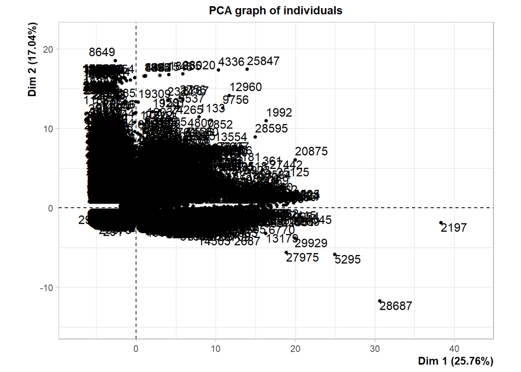

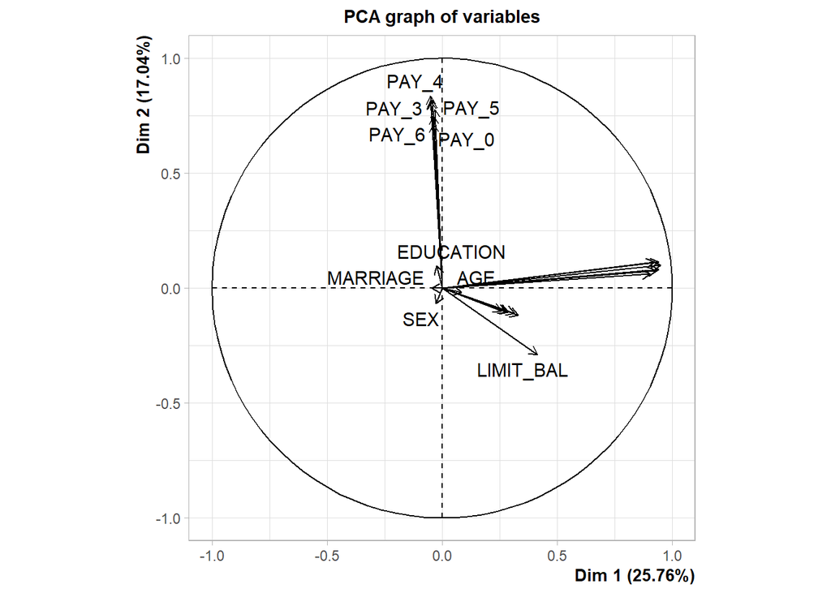

```
## **Results for the Principal Component Analysis (PCA)**
## The analysis was performed on 29965 individuals, described by 23 variables
## *The results are available in the following objects:
##
##    name               description
## 1  "$eig"             "eigenvalues"
## 2  "$var"             "results for the variables"
## 3  "$var$coord"       "coord. for the variables"
## 4  "$var$cor"         "correlations variables - dimensions"
## 5  "$var$cos2"        "cos2 for the variables"
## 6  "$var$contrib"     "contributions of the variables"
## 7  "$ind"             "results for the individuals"
## 8  "$ind$coord"       "coord. for the individuals"
## 9  "$ind$cos2"        "cos2 for the individuals"
## 10 "$ind$contrib"     "contributions of the individuals"
## 11 "$call"            "summary statistics"
## 12 "$call$centre"     "mean of the variables"
## 13 "$call$ecart.type" "standard error of the variables"
## 14 "$call$row.w"      "weights for the individuals"
## 15 "$call$col.w"      "weights for the variables"
```

```r
# Data standardization

library(FactoMineR)

PCA(def_pca, scale.unit = TRUE, ncp = 5, graph = TRUE)
```

```r
# computing principal component analysis on the active individuals/variables

library("FactoMineR")

res.pca <- PCA(def_pca, graph = FALSE)

print(res.pca)
```

```
## **Results for the Principal Component Analysis (PCA)**
## The analysis was performed on 29965 individuals, described by 23 variables
## *The results are available in the following objects:
##
##    name               description
## 1  "$eig"             "eigenvalues"
## 2  "$var"             "results for the variables"
## 3  "$var$coord"       "coord. for the variables"
## 4  "$var$cor"         "correlations variables - dimensions"
## 5  "$var$cos2"        "cos2 for the variables"
## 6  "$var$contrib"     "contributions of the variables"
## 7  "$ind"             "results for the individuals"
## 8  "$ind$coord"       "coord. for the individuals"
## 9  "$ind$cos2"        "cos2 for the individuals"
## 10 "$ind$contrib"     "contributions of the individuals"
## 11 "$call"            "summary statistics"
## 12 "$call$centre"     "mean of the variables"
## 13 "$call$ecart.type" "standard error of the variables"
## 14 "$call$row.w"      "weights for the individuals"
## 15 "$call$col.w"      "weights for the variables"
```

```r
#We examine the eigenvalues to determine the number of principal components to be considered.
library("factoextra")
eig.val <- get_eigenvalue(res.pca)
eig.val
```

```
##        eigenvalue variance.percent cumulative.variance.percent
## Dim.1  5.92507951       25.7612153                    25.76122
## Dim.2  3.91830732       17.0361188                    42.79733
## Dim.3  1.65838618        7.2103747                    50.00771
## Dim.4  1.51674399        6.5945391                    56.60225
## Dim.5  1.04862276        4.5592294                    61.16148
## Dim.6  1.01363125        4.4070924                    65.56857
## Dim.7  0.95455276        4.1502294                    69.71880
## Dim.8  0.88445086        3.8454385                    73.56424
## Dim.9  0.88335922        3.8406923                    77.40493
## Dim.10 0.86794230        3.7736622                    81.17859
## Dim.11 0.77956967        3.3894333                    84.56803
## Dim.12 0.73067203        3.1768349                    87.74486
## Dim.13 0.59772492        2.5988040                    90.34366
## Dim.14 0.54199018        2.3564790                    92.70014
## Dim.15 0.48597307        2.1129264                    94.81307
## Dim.16 0.33741349        1.4670152                    96.28008
## Dim.17 0.26004303        1.1306219                    97.41071
## Dim.18 0.24665073        1.0723945                    98.48310
## Dim.19 0.18842111        0.8192222                    99.30232
## Dim.20 0.07085596        0.3080694                    99.61039
## Dim.21 0.04104030        0.1784361                    99.78883
## Dim.22 0.02532961        0.1101287                    99.89896
## Dim.23 0.02323974        0.1010424                   100.00000
```

The sum of all the eigenvalues give a total variance of 23.

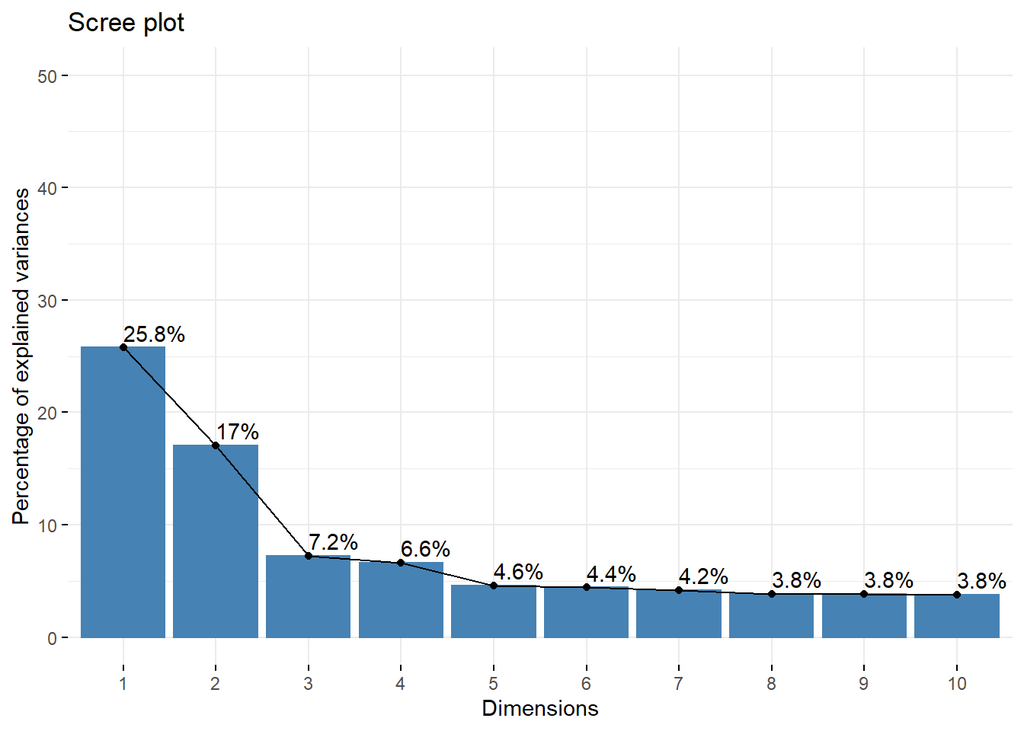

```r
# plotting a scree plot to identify the optimum number of dimensions to use
fviz_eig(res.pca, addlabels = TRUE, ylim = c(0, 50))
```

```r
# extracting the results for the PCA
var <- get_pca_var(res.pca)
var
```

```
## Principal Component Analysis Results for variables
##  ===================================================
##   Name       Description
## 1 "$coord"   "Coordinates for the variables"
## 2 "$cor"     "Correlations between variables and dimensions"
## 3 "$cos2"    "Cos2 for the variables"
## 4 "$contrib" "contributions of the variables"
```

```r
# extracting contribution of different variables
head(var$contrib, 5)
```

```
##                 Dim.1        Dim.2       Dim.3      Dim.4     Dim.5
## LIMIT_BAL 2.886755696 2.137074e+00 6.366887566  0.8597819 22.997194
## SEX       0.011151680 1.149329e-01 0.000588969  0.3533803  5.412033
## EDUCATION 0.008973715 2.381008e-01 3.243838454 13.1600225 46.230620
## MARRIAGE  0.032432666 7.854411e-06 0.008995245 41.3015043  1.826677
## AGE       0.117451244 8.879663e-03 0.036747408 43.8982570  2.463585
```

The larger the value of the contribution, the more the variable contributes to the component.

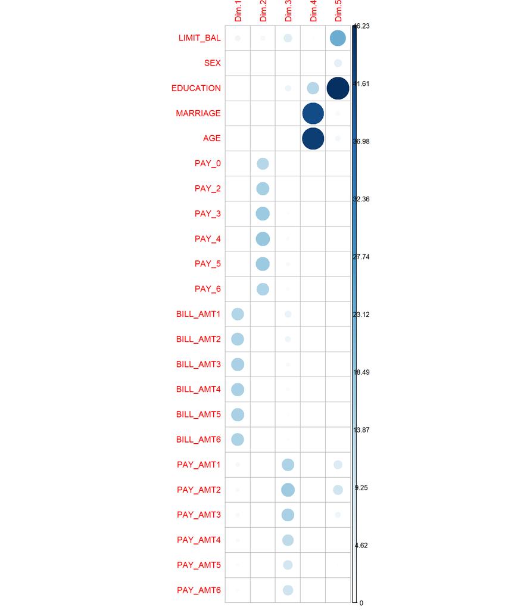

```r
# highlighting the most contributing variables for each dimension:

library("corrplot")
corrplot(var$contrib, is.corr=FALSE)
```

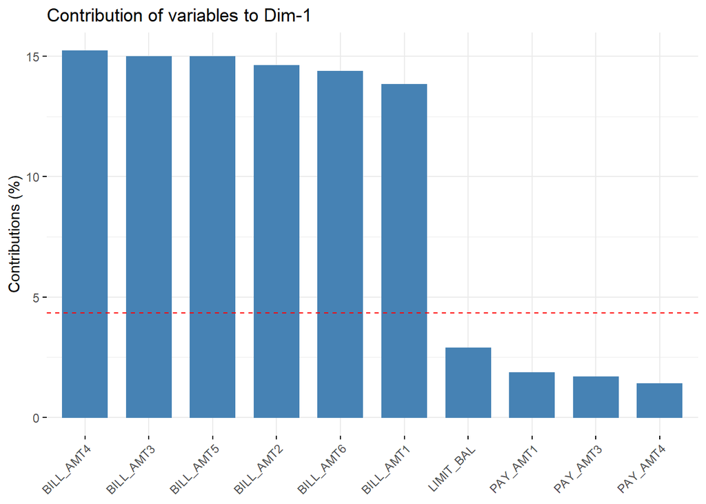

```r
# Contributions of variables to PC1
fviz_contrib(res.pca, choice = "var", axes = 1, top = 10)
```

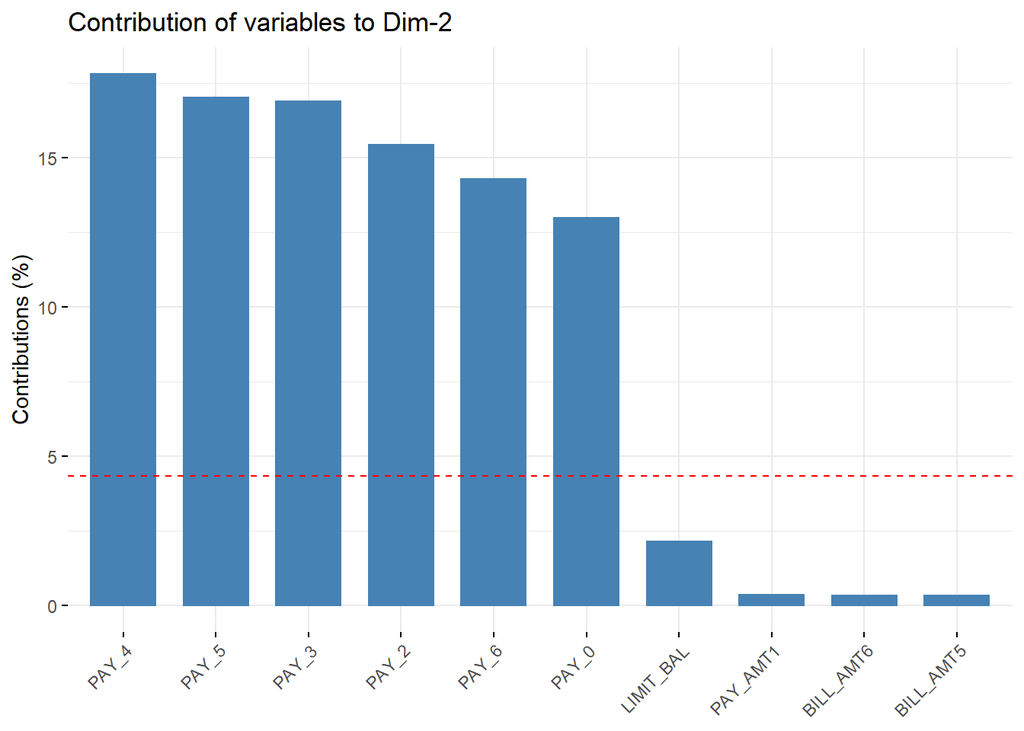

```r
# Contributions of variables to PC2
fviz_contrib(res.pca, choice = "var", axes = 2, top = 10)
```

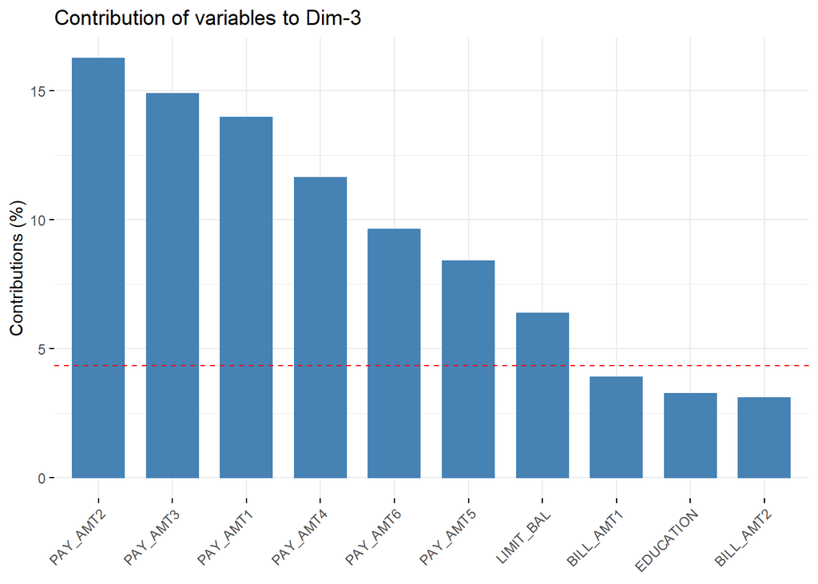

```r
# Contributions of variables to PC3
fviz_contrib(res.pca, choice = "var", axes = 3, top = 10)
```

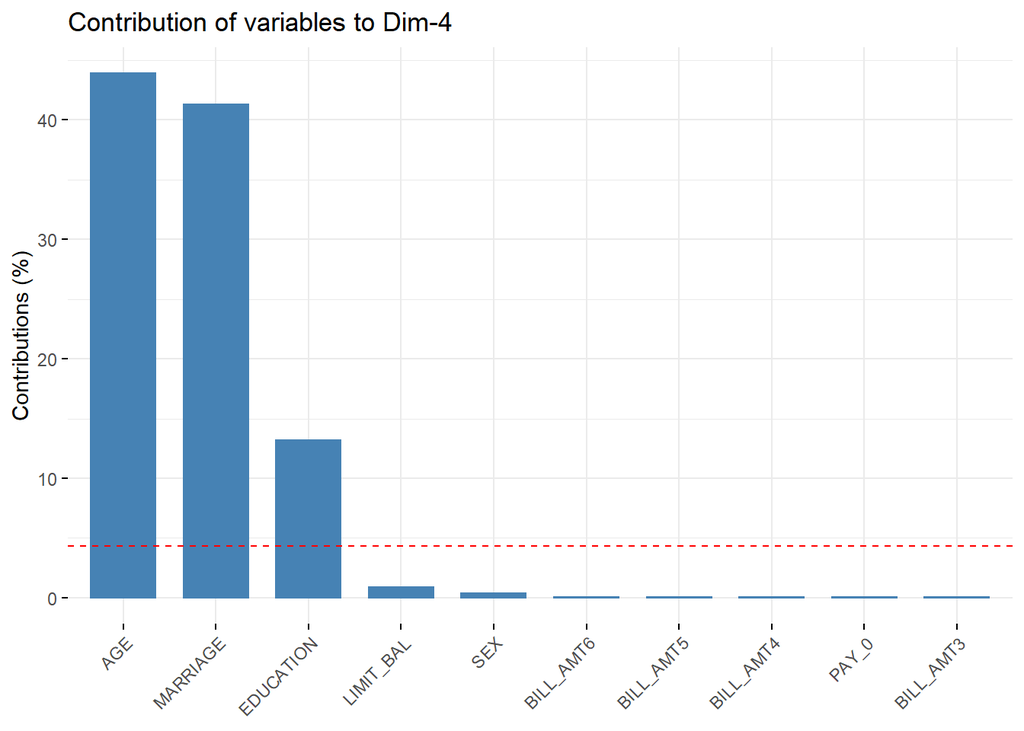

```r
# Contributions of variables to PC4
fviz_contrib(res.pca, choice = "var", axes = 4, top = 10)
```